# Capture-recapture analysis using ‘marked’

Viorel Popescu

2024-03-11

*Modern Methods in Ecological Modeling, Kunming Institute of Zoology, April 2024*

An alternative to the much **beloved program MARK** is the R package *‘marked’*, developed by Jeff Laake and collaborators (Laake et al. 2013). The full citation for this package is below, and the vignette that explains the reasoning behind the development of this package can be found here:

- Marked Vignette (https://cran.r-project.org/web/packages/marked/vignettes/markedVignette.pdf) Laake, J.L., D.S. Johnson, and P.B. Conn. 2013. marked: An R package for maximum-likelihood and MCMC analysis of capture-recapture data. Methods Ecol. Evol. 4:885-890.

In general, the package ‘marked’ aims to ease the implementation of capture-recapture models, and add other methods not available in program MARK.

## LET’S START CODING!!!

First, install the package ‘marked’ and call it into R. Then set the working directory to the capture-recapture file provided (AA for marked.txt). This dataset if for two colonies of swifts (Apus apus), a small insectivorous bird. The dataset contains two colonies, coded “G” (good) and “P” (poor), and the goal is to evaluate differences in apparent survival and recapture probability between the two colonies. However, this dataset can be used to examine trends in survival through time and other explorations.

```r
#install.packages("marked")
library(marked)
setwd('C:\\Users\\viore\\Dropbox\\Columbia\\KIZ\\workshop materials\\capture-recapture')
```

Next, you need to ask R to correctly read the recapture history as a *character*, and the grouping variable (colony in this case) as a *factor*. Otherwise, R will mess up and everything will be converted to integers, which ‘marked’ will absolutely **hate**. To do so, you need to use the *colClasses* function as described below.

```r
AA <- read.table("AA for marked.txt", colClasses=c("character","numeric","factor"), header=T)

# let's check out the structure of this file to make sure the
# correct variables types are read into R
str(AA)
```

```
## 'data.frame':    128 obs. of  3 variables:
##  $ ch    : chr  "11100000" "11100000" "11001000" "11000000" ...
##  $ freq  : num  1 1 1 1 1 1 1 1 1 1 ...
##  $ colony: Factor w/ 2 levels "G","P": 2 2 2 2 2 2 2 2 2 2 ...
```

```r
head(AA)
```

```
##         ch freq colony
## 1 11100000    1      P
## 2 11100000    1      P
## 3 11001000    1      P
## 4 11000000    1      P
## 5 10000000    1      P
## 6 10000000    1      P
```

We can now start processing the data to create the input files for *‘marked’*. The process is similar to the one that we implemented using package *‘RMark’*. First, we use the *process.data* function to declare that this is Cormack-Jolly-Seber model, and the groups that we are interested in (in this case, colony). Then, function *make.design.data* will create the design matrix for this dataset.

```r
AA.proc <- process.data(AA,model="CJS", groups = "colony")
```

[output not shown]

```r
AA.ddl <- make.design.data(AA.proc)
```

We now have all the building blocks to start parameterizing capture-recapture models! So, let’s try to run a model using *‘marked’*! Let’s model survival probability (**Phi**) as a function of *colony* and *time*, and recapture probability (**p**) as a function of time. The formulas below are intuitive

```r
mod.Phicolonytime.ptime <- crm(AA.proc,AA.ddl, model = 'csj', groups = "colony",
                    model.parameters = list(Phi = list(formula=~colony+time),
                                            p = list(formula=~time)),hessian=T)
```

```
## Computing initial parameter estimates
```

```
## Starting optimization for 15 parameters...
```

```
##
 Number of evaluations:  100  -2lnl: 349.1280903
 Number of evaluations:  200  -2lnl: 348.5935256
 Number of evaluations:  300  -2lnl: 348.5072005
 Number of evaluations:  400  -2lnl: 348.4964846
 Number of evaluations:  500  -2lnl:  348.494578
 Number of evaluations:  600  -2lnl: 348.4945287
 Number of evaluations:  700  -2lnl: 348.4944854
 Number of evaluations:  800  -2lnl:  348.494285
 Number of evaluations:  900  -2lnl:  348.494091
 Number of evaluations:  1000  -2lnl: 348.4940416
 Number of evaluations:  1100  -2lnl: 348.5555253
 Number of evaluations:  1200  -2lnl: 348.5003491
 Number of evaluations:  1300  -2lnl: 352.3140215
 Number of evaluations:  1400  -2lnl: 348.5375031
 Number of evaluations:  1500  -2lnl: 348.7785062
 Number of evaluations:  1600  -2lnl: 348.4993946
 Number of evaluations:  1700  -2lnl: 348.5710292
 Number of evaluations:  1800  -2lnl: 348.4989013
 Number of evaluations:  1900  -2lnl: 348.5692899
 Number of evaluations:  2000  -2lnl: 348.4940372
```

```
## Computing hessian...
```

```
##
 Number of evaluations:  100  -2lnl: 348.4942974
 Number of evaluations:  200  -2lnl: 348.4990436
 Number of evaluations:  300  -2lnl: 349.3095197
 Number of evaluations:  400  -2lnl: 348.5381974
 Number of evaluations:  500  -2lnl: 348.7457936
 Number of evaluations:  600  -2lnl: 348.5027444
 Number of evaluations:  700  -2lnl: 348.5249695
 Number of evaluations:  800  -2lnl: 348.4962154
 Number of evaluations:  900  -2lnl: 348.5265758
```

```
##
## Elapsed time in minutes:  0.0053
```

```r
# let's check out the results! Copy and paste them into a document,
# as we will want to compare them to the results from RMark.
mod.Phicolonytime.ptime
```

```
##
## crm Model Summary
##
## Npar :  15
## -2lnL:  348.494
## AIC  :  378.494
##
## Beta
##                   Estimate         se          lcl        ucl
## Phi.(Intercept)  2.1294063  0.8779476   0.40862893  3.8501836
## Phi.colonyP     -0.9096433  0.3953062  -1.68444339 -0.1348432
## Phi.time2       -0.9751966  1.0292568  -2.99254002  1.0421468
## Phi.time3       -0.7898114  1.1398784  -3.02397320  1.4443503
## Phi.time4       -1.0284586  1.0302029  -3.04765614  0.9907390
## Phi.time5       -1.1838008  0.9795458  -3.10371048  0.7361089
## Phi.time6       -0.9013141  1.0771569  -3.01254172  1.2099135
## Phi.time7       -2.5284047  3.6806321  -9.74244349  4.6856342
## p.(Intercept)    2.0351810  1.0479990  -0.01889696  4.0892589
## p.time3         -1.0289752  1.1970185  -3.37513140  1.3171810
## p.time4         -1.9414541  1.1607308  -4.21648649  0.3335783
## p.time5         -1.2247431  1.1728085  -3.52344768  1.0739615
## p.time6         -0.1168109  1.2906335  -2.64645246  2.4128308
## p.time7         -0.1759765  1.4898294  -3.09604208  2.7440891
## p.time8          0.5096053 30.9727127 -60.19691150 61.2161222
```

```r
mod.Phicolony.ptime <- crm(AA.proc,AA.ddl, model = 'csj', groups = "colony",
                    model.parameters = list(Phi = list(formula=~1),
                                            p = list(formula=~1)),hessian=T)
```

```
## Computing initial parameter estimates
```

```
## Starting optimization for 2 parameters...
```

```
## Computing hessian...
```

```
##
## Elapsed time in minutes:  0.0018
```

```r
# let's check out the results! Copy and paste them into a document,
# as we will want to compare them to the results from RMark.
mod.Phicolony.ptime
```

```
##
## crm Model Summary
##
## Npar :  2
## -2lnL:  372.8533
## AIC  :  376.8533
##
## Beta
##                  Estimate        se       lcl      ucl
## Phi.(Intercept) 0.8524700 0.1753815 0.5087222 1.196218
## p.(Intercept)   0.8880919 0.2391854 0.4192885 1.356895
```

Also, let’s compute the ‘real’ parameter estimates

```r
#phis <- compute.real(mod.Phisex.pdot,"Phi",unique=TRUE,vcv=TRUE)
phis <- predict(mod.Phicolony.ptime)$Phi
phis
```

```
##   occ estimate        se       lcl       ucl
## 1   7 0.701085 0.0367538 0.6245069 0.7678513
```

```r
ps <- predict(mod.Phicolony.ptime)$p
ps
```

```
##   occ  estimate         se      lcl       ucl
## 1   8 0.7084962 0.04939879 0.603313 0.7952546
```

Run several other models using the code above and let’s explore other model parameterizations. 1) code Phi AND p as a function of ‘time’ 2) code Phi AND p as ‘time-invariant’ (no change through ‘time’ or by ‘colony’) 3) code Phi as a function of ‘colony’ and p as a function of ‘time’ and ‘colony’

## Run multiple models (and create a function to do so!!!)

One the advantages of using *‘marked’* is that one can perform multiple model fitting at once. For this we can create a “wrapper”, or a function that will allow us to fit all possible combinations of **Phi** and **p** submodels. We need to declare each type of submodel for calculating survival and recapture probabilities as a function of our covariates of interest (colony and time in our case).

```r
fit.models=function()
   {

   #declare all the combinations of variables for survival and recapture

      Phi.dot = list(formula=~1)  # survival is constant
      Phi.colony = list(formula=~colony)  # survival varies by colony
      Phi.time = list(formula=~time)  # survival varies by time
      Phi.colony.time = list(formula=~colony+time)  # survival by colony and time
      p.dot = list(formula=~1)  # recapture is constant
      p.colony = list(formula=~colony)  # recapture varies by colony
      p.time = list(formula=~time)  # recapture varies by time
      p.colony.time = list(formula=~colony+time)  # recapture by colony and time


   # create a list of all possible models containing Phi and p
   # (all combinaitons of the above submodels)
     cml=create.model.list(c("Phi","p"))

   # Run all the models at once using the model list,  data and design matrices
     results=crm.wrapper(cml,data=AA.proc, ddl=AA.ddl,
                         external=FALSE,accumulate=FALSE,
                         method="Nelder-Mead",hessian=TRUE)

   # Now use function 'return' to colect all the models
     return(results)
     }
```

You will notice that nothing happended, and no models were run. This is because we just ‘declared’ the function to R, and now R is ready to receive the command Now, we use our newly created function **fit.models** to fit the models and collect the outputs.

```r
AA.models=fit.models()
```

```
## Phi.colony.p.colony
```

```
## Computing initial parameter estimates
```

```
## Starting optimization for 4 parameters...
```

```
##
 Number of evaluations:  100  -2lnl: 365.7940543
 Number of evaluations:  200  -2lnl: 365.7940546
```

```
## Computing hessian...
```

```
##
## Elapsed time in minutes:  0.0022
```

```
## Phi.colony.p.colony.time
```

```
## Computing initial parameter estimates
```

```
## Starting optimization for 10 parameters...
```

```
##
 Number of evaluations:  100  -2lnl:  349.275266
 Number of evaluations:  200  -2lnl: 348.4758804
 Number of evaluations:  300  -2lnl: 348.4164799
 Number of evaluations:  400  -2lnl: 348.4113116
 Number of evaluations:  500  -2lnl: 348.4106247
 Number of evaluations:  600  -2lnl: 348.4104715
 Number of evaluations:  700  -2lnl:  348.409378
 Number of evaluations:  800  -2lnl: 348.5089234
 Number of evaluations:  900  -2lnl: 348.4075777
 Number of evaluations:  1000  -2lnl: 348.4133423
 Number of evaluations:  1100  -2lnl: 348.4134933
```

```
## Computing hessian...
```

```
##
 Number of evaluations:  100  -2lnl:  349.629449
 Number of evaluations:  200  -2lnl: 348.4154281
 Number of evaluations:  300  -2lnl: 348.4494108
 Number of evaluations:  400  -2lnl:  348.429668
```

```
##
## Elapsed time in minutes:  0.003
```

```
## Phi.colony.p.dot
```

```
## Computing initial parameter estimates
```

```
## Starting optimization for 3 parameters...
```

```
##
 Number of evaluations:  100  -2lnl:  367.445213
```

```
## Computing hessian...
```

```
##
## Elapsed time in minutes:  0.0017
```

```
## Phi.colony.p.time
```

```
## Computing initial parameter estimates
```

```
## Starting optimization for 9 parameters...
```

[output not shown]

```
## Computing hessian...
```

```
##
 Number of evaluations:  100  -2lnl:  351.731093
 Number of evaluations:  200  -2lnl:   351.18617
 Number of evaluations:  300  -2lnl: 352.1522408
```

```
##
## Elapsed time in minutes:  0.0042
```

```
## Phi.colony.time.p.colony
```

```
## Computing initial parameter estimates
```

```
## Starting optimization for 10 parameters...
```

```
##
 Number of evaluations:  100  -2lnl: 354.1803179
 Number of evaluations:  200  -2lnl: 354.0848767
 Number of evaluations:  300  -2lnl: 354.0415298
 Number of evaluations:  400  -2lnl: 354.0105009
 Number of evaluations:  500  -2lnl: 353.9172951
 Number of evaluations:  600  -2lnl: 353.7898665
 Number of evaluations:  700  -2lnl: 353.7444591
 Number of evaluations:  800  -2lnl: 353.7336578
 Number of evaluations:  900  -2lnl: 353.7265967
 Number of evaluations:  1000  -2lnl: 353.7232777
 Number of evaluations:  1100  -2lnl: 353.7208589
 Number of evaluations:  1200  -2lnl: 353.7184978
 Number of evaluations:  1300  -2lnl: 353.7155746
 Number of evaluations:  1400  -2lnl: 353.7142212
 Number of evaluations:  1500  -2lnl: 353.7139661
 Number of evaluations:  1600  -2lnl: 353.7137707
 Number of evaluations:  1700  -2lnl: 353.7137023
 Number of evaluations:  1800  -2lnl: 353.9599518
 Number of evaluations:  1900  -2lnl: 353.7547376
 Number of evaluations:  2000  -2lnl: 354.0529418
 Number of evaluations:  2100  -2lnl: 353.7424616
 Number of evaluations:  2200  -2lnl: 354.5697787
```

```
## Computing hessian...
```

```
##
 Number of evaluations:  100  -2lnl: 354.0920412
 Number of evaluations:  200  -2lnl: 353.7334103
 Number of evaluations:  300  -2lnl: 354.6707578
 Number of evaluations:  400  -2lnl: 353.7349991
```

```
##
## Elapsed time in minutes:  0.0038
```

```
## Phi.colony.time.p.colony.time
```

```
## Computing initial parameter estimates
```

```
## Starting optimization for 16 parameters...
```

[output not shown]

```
## Computing hessian...
```

```
##
 Number of evaluations:  100  -2lnl: 346.0700563
 Number of evaluations:  200  -2lnl: 345.9980013
 Number of evaluations:  300  -2lnl: 349.3363032
 Number of evaluations:  400  -2lnl: 346.0261727
 Number of evaluations:  500  -2lnl: 346.1112347
 Number of evaluations:  600  -2lnl: 346.0126879
 Number of evaluations:  700  -2lnl: 346.0697552
 Number of evaluations:  800  -2lnl:  345.981271
 Number of evaluations:  900  -2lnl: 346.0208352
 Number of evaluations:  1000  -2lnl: 345.9896692
```

```
##
## Elapsed time in minutes:  0.0058
```

```
## Phi.colony.time.p.dot
```

```
## Computing initial parameter estimates
```

```
## Starting optimization for 9 parameters...
```

```
##
 Number of evaluations:  100  -2lnl: 355.8409996
 Number of evaluations:  200  -2lnl: 355.8145461
 Number of evaluations:  300  -2lnl: 355.7780084
 Number of evaluations:  400  -2lnl: 355.7484578
 Number of evaluations:  500  -2lnl: 355.7087625
 Number of evaluations:  600  -2lnl: 355.6858738
 Number of evaluations:  700  -2lnl: 355.6604769
 Number of evaluations:  800  -2lnl: 355.6365222
 Number of evaluations:  900  -2lnl: 355.6346164
 Number of evaluations:  1000  -2lnl: 355.6340925
 Number of evaluations:  1100  -2lnl: 355.6339351
 Number of evaluations:  1200  -2lnl: 355.8512727
 Number of evaluations:  1300  -2lnl: 355.8335759
 Number of evaluations:  1400  -2lnl: 355.6768899
 Number of evaluations:  1500  -2lnl:  355.633932
```

```
## Computing hessian...
```

```
##
 Number of evaluations:  100  -2lnl: 358.7893719
 Number of evaluations:  200  -2lnl: 355.7909602
 Number of evaluations:  300  -2lnl: 358.7867199
```

```
##
## Elapsed time in minutes:  0.003
```

```
## Phi.colony.time.p.time
```

```
## Computing initial parameter estimates
```

```
## Starting optimization for 15 parameters...
```

[output not shown]

```
## Computing hessian...
```

```
##
 Number of evaluations:  100  -2lnl: 348.5122034
 Number of evaluations:  200  -2lnl: 348.5195435
 Number of evaluations:  300  -2lnl: 349.0958953
 Number of evaluations:  400  -2lnl: 348.5445023
 Number of evaluations:  500  -2lnl: 348.7273966
 Number of evaluations:  600  -2lnl: 348.5201446
 Number of evaluations:  700  -2lnl:  348.538093
 Number of evaluations:  800  -2lnl:  348.513054
 Number of evaluations:  900  -2lnl:  348.543907
```

```
##
## Elapsed time in minutes:  0.0053
```

```
## Phi.dot.p.colony
```

```
## Computing initial parameter estimates
```

```
## Starting optimization for 3 parameters...
```

```
##
 Number of evaluations:  100  -2lnl: 367.9426393
```

```
## Computing hessian...
```

```
##
## Elapsed time in minutes:  0.0018
```

```
## Phi.dot.p.colony.time
```

```
## Computing initial parameter estimates
```

```
## Starting optimization for 9 parameters...
```

[output not shown]

```
## Computing hessian...
```

```
##
 Number of evaluations:  100  -2lnl: 351.3401729
 Number of evaluations:  200  -2lnl:  350.865228
 Number of evaluations:  300  -2lnl: 351.9726156
```

```
##
## Elapsed time in minutes:  0.0038
```

```
## Phi.dot.p.dot
```

```
## Computing initial parameter estimates
```

```
## Starting optimization for 2 parameters...
```

```
## Computing hessian...
```

```
##
## Elapsed time in minutes:  0.0018
```

```
## Phi.dot.p.time
```

```
## Computing initial parameter estimates
```

```
## Starting optimization for 8 parameters...
```

```
##
 Number of evaluations:  100  -2lnl: 357.0110736
 Number of evaluations:  200  -2lnl: 356.8573419
 Number of evaluations:  300  -2lnl: 356.8538776
 Number of evaluations:  400  -2lnl: 356.8399705
 Number of evaluations:  500  -2lnl: 356.7283767
 Number of evaluations:  600  -2lnl:  356.602024
 Number of evaluations:  700  -2lnl: 356.5415948
 Number of evaluations:  800  -2lnl: 356.5265287
 Number of evaluations:  900  -2lnl: 356.5259797
 Number of evaluations:  1000  -2lnl: 356.5240657
 Number of evaluations:  1100  -2lnl: 356.5215593
 Number of evaluations:  1200  -2lnl: 356.5186872
 Number of evaluations:  1300  -2lnl: 356.5070138
 Number of evaluations:  1400  -2lnl:  356.501946
 Number of evaluations:  1500  -2lnl: 356.4992394
 Number of evaluations:  1600  -2lnl: 356.4972566
 Number of evaluations:  1700  -2lnl: 356.4971664
 Number of evaluations:  1800  -2lnl: 356.6204378
 Number of evaluations:  1900  -2lnl:  356.683462
 Number of evaluations:  2000  -2lnl:   356.55338
```

```
## Computing hessian...
```

```
##
 Number of evaluations:  100  -2lnl: 358.3035616
 Number of evaluations:  200  -2lnl: 356.5845211
```

```
##
## Elapsed time in minutes:  0.0033
```

```
## Phi.time.p.colony
```

```
## Computing initial parameter estimates
```

```
## Starting optimization for 9 parameters...
```

```
##
 Number of evaluations:  100  -2lnl: 357.9307434
 Number of evaluations:  200  -2lnl: 357.7330116
 Number of evaluations:  300  -2lnl:  357.730566
 Number of evaluations:  400  -2lnl: 357.7295429
 Number of evaluations:  500  -2lnl: 357.7292585
 Number of evaluations:  600  -2lnl: 357.7286597
 Number of evaluations:  700  -2lnl: 357.7278557
 Number of evaluations:  800  -2lnl: 357.7254581
 Number of evaluations:  900  -2lnl: 357.7203048
 Number of evaluations:  1000  -2lnl: 357.7183014
 Number of evaluations:  1100  -2lnl: 357.7169946
 Number of evaluations:  1200  -2lnl:  357.707332
 Number of evaluations:  1300  -2lnl: 357.7022498
 Number of evaluations:  1400  -2lnl: 357.7006856
 Number of evaluations:  1500  -2lnl: 357.6993002
 Number of evaluations:  1600  -2lnl: 357.6945139
 Number of evaluations:  1700  -2lnl: 357.6920613
 Number of evaluations:  1800  -2lnl: 357.6918202
 Number of evaluations:  1900  -2lnl:  358.127408
 Number of evaluations:  2000  -2lnl: 357.7508255
 Number of evaluations:  2100  -2lnl: 358.1443137
 Number of evaluations:  2200  -2lnl: 357.6917846
```

```
## Computing hessian...
```

```
##
 Number of evaluations:  100  -2lnl: 358.9659579
 Number of evaluations:  200  -2lnl: 357.7857732
 Number of evaluations:  300  -2lnl: 359.1407369
```

```
##
## Elapsed time in minutes:  0.0035
```

```
## Phi.time.p.colony.time
```

```
## Computing initial parameter estimates
```

```
## Starting optimization for 15 parameters...
```

[output not shown]

```
## Computing hessian...
```

```
##
 Number of evaluations:  100  -2lnl:  348.858509
 Number of evaluations:  200  -2lnl: 348.8652799
 Number of evaluations:  300  -2lnl: 349.9212357
 Number of evaluations:  400  -2lnl:  348.874913
 Number of evaluations:  500  -2lnl: 349.0058044
 Number of evaluations:  600  -2lnl: 348.8659002
 Number of evaluations:  700  -2lnl: 349.1022035
 Number of evaluations:  800  -2lnl: 348.8812473
 Number of evaluations:  900  -2lnl: 349.4038672
```

```
##
## Elapsed time in minutes:  0.0062
```

```
## Phi.time.p.dot
```

```
## Computing initial parameter estimates
```

```
## Starting optimization for 8 parameters...
```

```
##
 Number of evaluations:  100  -2lnl: 362.5101288
 Number of evaluations:  200  -2lnl: 362.4457288
 Number of evaluations:  300  -2lnl:  362.404363
 Number of evaluations:  400  -2lnl:  362.397161
 Number of evaluations:  500  -2lnl: 362.3864759
 Number of evaluations:  600  -2lnl: 362.3787308
 Number of evaluations:  700  -2lnl: 362.3688183
 Number of evaluations:  800  -2lnl: 362.3662548
 Number of evaluations:  900  -2lnl: 362.3649273
 Number of evaluations:  1000  -2lnl: 362.3629641
 Number of evaluations:  1100  -2lnl: 362.3567431
 Number of evaluations:  1200  -2lnl: 362.3529232
 Number of evaluations:  1300  -2lnl: 362.3487758
 Number of evaluations:  1400  -2lnl: 362.3473888
 Number of evaluations:  1500  -2lnl: 362.3472652
 Number of evaluations:  1600  -2lnl: 362.3365458
 Number of evaluations:  1700  -2lnl: 362.3518035
 Number of evaluations:  1800  -2lnl: 362.5028051
 Number of evaluations:  1900  -2lnl:   362.34724
```

```
## Computing hessian...
```

```
##
 Number of evaluations:  100  -2lnl: 362.3809951
 Number of evaluations:  200  -2lnl: 362.3893467
```

```
##
## Elapsed time in minutes:  0.0032
```

```
## Phi.time.p.time
```

```
## Computing initial parameter estimates
```

```
## Starting optimization for 14 parameters...
```

```
##
 Number of evaluations:  100  -2lnl: 355.1541822
 Number of evaluations:  200  -2lnl: 355.0249331
 Number of evaluations:  300  -2lnl: 354.9681065
 Number of evaluations:  400  -2lnl: 354.9625952
 Number of evaluations:  500  -2lnl: 354.9585813
 Number of evaluations:  600  -2lnl:  354.952868
 Number of evaluations:  700  -2lnl: 354.9512202
 Number of evaluations:  800  -2lnl: 354.9504169
 Number of evaluations:  900  -2lnl:  354.950059
 Number of evaluations:  1000  -2lnl: 354.9498273
 Number of evaluations:  1100  -2lnl: 354.9496849
 Number of evaluations:  1200  -2lnl: 354.9495093
 Number of evaluations:  1300  -2lnl:  354.949445
 Number of evaluations:  1400  -2lnl:  356.335332
 Number of evaluations:  1500  -2lnl: 354.9494131
 Number of evaluations:  1600  -2lnl: 355.0146505
 Number of evaluations:  1700  -2lnl: 354.9881109
 Number of evaluations:  1800  -2lnl: 356.5455541
 Number of evaluations:  1900  -2lnl: 354.9567978
 Number of evaluations:  2000  -2lnl: 355.5439534
 Number of evaluations:  2100  -2lnl: 354.9869317
 Number of evaluations:  2200  -2lnl: 354.9767106
 Number of evaluations:  2300  -2lnl: 354.9494108
```

```
## Computing hessian...
```

```
##
 Number of evaluations:  100  -2lnl: 354.9494284
 Number of evaluations:  200  -2lnl: 355.0426489
 Number of evaluations:  300  -2lnl: 355.5785804
 Number of evaluations:  400  -2lnl: 354.9949216
 Number of evaluations:  500  -2lnl: 355.0687992
 Number of evaluations:  600  -2lnl: 354.9507636
 Number of evaluations:  700  -2lnl: 355.5525296
 Number of evaluations:  800  -2lnl: 354.9870706
```

```
##
## Elapsed time in minutes:  0.0038
```

```r
AA.models
```

```
##                                   model npar      AIC   DeltaAIC       weight
## 2         Phi(~colony)p(~colony + time)   10 368.4104  0.0000000 0.3265872765
## 10             Phi(~1)p(~colony + time)    9 368.8183  0.4078330 0.2663418795
## 4                  Phi(~colony)p(~time)    9 369.1493  0.7388963 0.2257095667
## 12                      Phi(~1)p(~time)    8 372.4971  4.0867278 0.0423231114
## 3                     Phi(~colony)p(~1)    3 373.4051  4.9946505 0.0268797172
## 7              Phi(~colony + time)p(~1)    9 373.6339  5.2235088 0.0239733506
## 5         Phi(~colony + time)p(~colony)   10 373.7137  5.3032550 0.0230362653
## 1                Phi(~colony)p(~colony)    4 373.7941  5.3836324 0.0221288240
## 9                     Phi(~1)p(~colony)    3 373.9378  5.5274130 0.0205938137
## 13                 Phi(~time)p(~colony)    9 375.6918  7.2813983 0.0085676892
## 11                         Phi(~1)p(~1)    2 376.8533  8.4428740 0.0047934971
## 6  Phi(~colony + time)p(~colony + time)   16 377.9875  9.5770688 0.0027187244
## 15                      Phi(~time)p(~1)    8 378.3472  9.9367987 0.0022711763
## 8           Phi(~colony + time)p(~time)   15 378.5122 10.1018039 0.0020913196
```

[output cut: 19 more lines]

Let’s investigate model predictions for survival and detection based on out top model, which is denoted as model ‘2’ in the AICc table above (see first table column). Are there significant differences in survival between the 2 colonies? HINT: evaluate whether the 95% confidence interval (denoted as ‘lcl’ (lower) and ‘ucl’ (upper)) overlap.

```r
Phi_by_colony <- predict(AA.models[[2]])$Phi
Phi_by_colony
```

```
##   colony occ  estimate         se       lcl       ucl
## 1      G   7 0.7624224 0.03916772 0.6774734 0.8305919
## 2      P   7 0.6201424 0.08179948 0.4525306 0.7632818
```

```r
p_by_colony.time <- predict(AA.models[[2]])$p
p_by_colony.time
```

```
##    colony time occ  estimate         se       lcl       ucl
## 1       G    8   8 0.5000919 0.09931512 0.3146944 0.6854642
## 2       P    8   8 0.2863913 0.12555027 0.1074505 0.5722654
## 3       G    7   7 0.8933244 0.09195268 0.5582146 0.9823011
## 4       P    7   7 0.7706198 0.18297337 0.3063953 0.9623359
## 5       G    6   6 0.8725235 0.08011259 0.6252129 0.9656162
## 6       P    6   6 0.7330425 0.17081098 0.3316590 0.9382498
## 7       G    5   5 0.7258153 0.09852698 0.5007783 0.8747771
## 8       P    5   5 0.5150330 0.17233532 0.2154839 0.8041571
## 9       G    4   4 0.5717045 0.11433807 0.3483217 0.7692431
## 10      G    3   3 0.7831106 0.09451955 0.5481401 0.9148709
## 11      P    3   3 0.5915902 0.15629061 0.2896019 0.8373177
## 12      P    4   4 0.3487508 0.15002405 0.1279518 0.6615304
## 13      G    2   2 0.8978559 0.08165052 0.6055457 0.9805186
## 14      P    2   2 0.7790745 0.15988715 0.3634443 0.9561025
```

Let’s plot the results of showing survival through time (although the time-dependent model did not come out as one of our top models). First, let’s pick a model that includes time as a variable for phi by checking he model number in the AICc table above (model 13 seems to be one we can use).

```r
Phi_by_year <- predict(AA.models[[13]])$Phi
Phi_by_year
```

```
##   time occ  estimate         se       lcl       ucl
## 1    7   7 0.4539154 0.09173345 0.2869558 0.6319262
## 2    6   6 0.7942935 0.11326963 0.4980624 0.9375999
## 3    5   5 0.7373795 0.10188470 0.5002967 0.8873145
## 4    4   4 0.7737623 0.10490436 0.5137749 0.9171503
## 5    3   3 0.6765229 0.10887327 0.4409600 0.8472176
## 6    2   2 0.7120812 0.10164699 0.4834489 0.8672956
## 7    1   1 0.8611367 0.11059376 0.5030146 0.9743560
```

Plot the estimates (‘estimate’ in our object above) and the 95% confidence intervals around those estimates (denoted as ‘ucl’ = upper confidence limit and ‘lcl’ = lower confidence limit).

```r
#install.packages("Hmisc")
library(Hmisc)
```

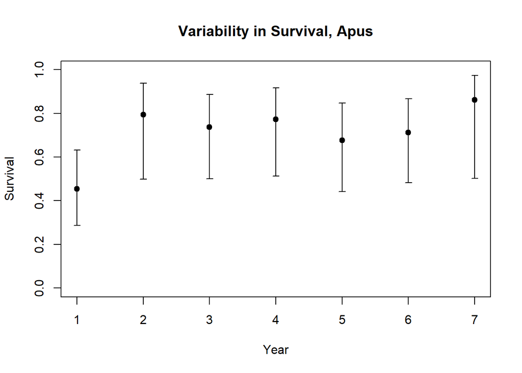

```r
plot(1:nrow(Phi_by_year),Phi_by_year$estimate,xlab="Year",ylab="Survival",
   ylim=c(0,1),main="Variability in Survival, Apus")
errbar(1:nrow(Phi_by_year),Phi_by_year$estimate,Phi_by_year$ucl,
   Phi_by_year$lcl,add=T)
```

How about quantifying the stochasticity in survival rates? For this, we need to calculate the standard deviation of the yearly survival estimates; note that we will ignore the variation around yearly estimates, and just use the mean survival estimates.

```r
mean(Phi_by_year$estimate)
```

```
## [1] 0.7155845
```

```r
sd(Phi_by_year$estimate)
```

```
## [1] 0.1299032
```

# The End! Isn’t Life Beautiful???